# IODS course project

Let’s also check for outliers with boxplots.

```r
RATSL_out <- data_RATSL %>%
  filter(Time > 0) %>%
  group_by(Group, ID) %>%
  summarise( mean=mean(Weight) ) %>%
  ungroup()
```

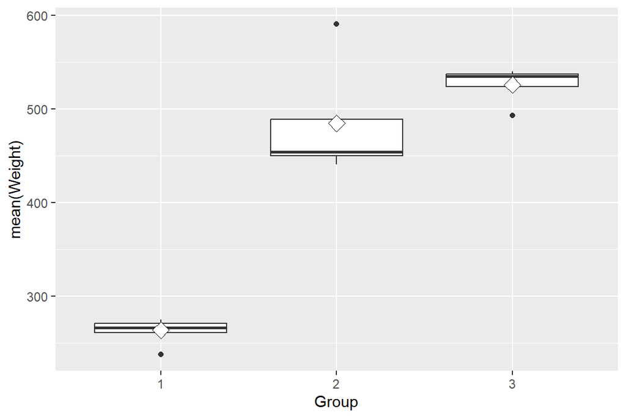

```r
ggplot(RATSL_out, aes(x = Group, y = mean)) +
  geom_boxplot() +
  stat_summary(fun = "mean", geom = "point", shape=23, size=4, fill = "white") +
  scale_y_continuous(name = "mean(Weight)")
```

It would seem like there is at least major outlier with group 2 that could be removed.

```r
RATSL_out1 <- RATSL_out %>%
  filter(mean < 570)
```

Let’s plot again.

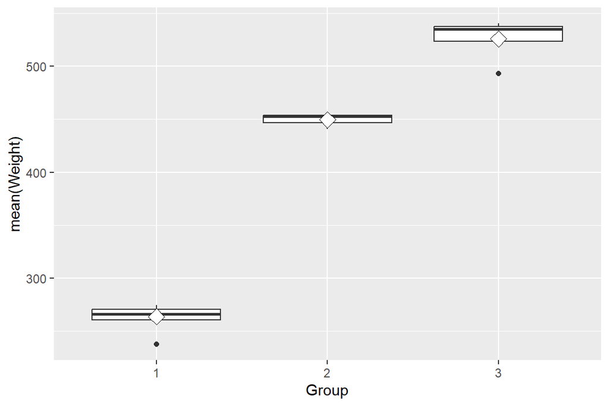

```r
ggplot(RATSL_out1, aes(x = Group, y = mean)) +
  geom_boxplot() +
  stat_summary(fun = "mean", geom = "point", shape=23, size=4, fill = "white") +
  scale_y_continuous(name = "mean(Weight)")
```

This had a major impact on the group 2. Its box became tighter and smaller. Maybe we can try this with group 1 also.

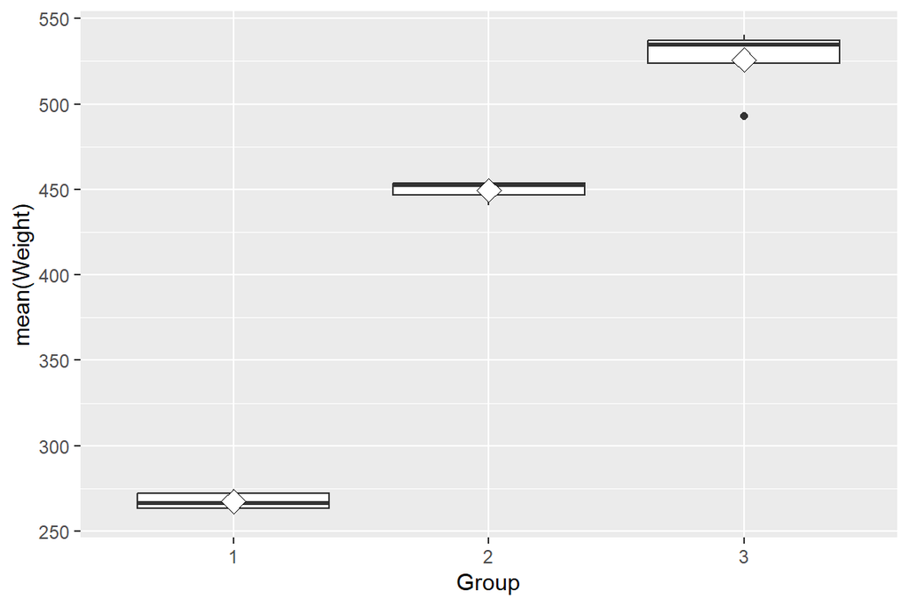

```r
RATSL_out2 <- RATSL_out1  %>%
  filter(mean > 240)

ggplot(RATSL_out2, aes(x = Group, y = mean)) +
  geom_boxplot() +
  stat_summary(fun = "mean", geom = "point", shape=23, size=4, fill = "white") +
  scale_y_continuous(name = "mean(Weight)")
```

With these test there might be a problems as there are only now only 3 rats in the group 2 as the outlier is removed. The effect of removing outlier is thus very big and impacts the results very much.

```r
#load in the original data
og_RATS <- read.table("https://raw.githubusercontent.com/KimmoVehkalahti/MABS/master/Examples/data/rats.txt", header = TRUE, sep = '\t')

#remove the rows (they are identified by hand)
data_RATSL_anova <- og_RATS[-c(2,12),]

RATSL_out2 <- RATSL_out2 %>%
  mutate(baseline = data_RATSL_anova$WD1)

# Fit the linear model with the mean as the response
rat_fit <- lm(mean ~baseline + Group, data = RATSL_out2)

#anova
anova(rat_fit)
```

```
## Analysis of Variance Table
##
## Response: mean
##           Df Sum Sq Mean Sq  F value    Pr(>F)
## baseline   1 188050  188050 3395.239 5.381e-14 ***
## Group      2   1362     681   12.291  0.002022 **
## Residuals 10    554      55
## ---
## Signif. codes:  0 '***' 0.001 '**' 0.01 '*' 0.05 '.' 0.1 ' ' 1
```

Baseline is highly significant. At least this tells us that the weights taken at baseline are highly relevant for the weights taken after the diet has begun. I did not find so much on what it actually tells us to use lm-model as an input for anova.